Pular para o conteúdo principal

# Juros e bolsa: como os setores da B3 reagem à Selic

Relatório de mercado — bancos, varejo e utilities, de jan/2015 a set/2026

Autores

Integrante 1

Integrante 2

Integrante 3

Integrante 4

Integrante 5

Data de Publicação

18 de novembro de 2026

Disciplina

REC3302 — Introdução ao R Aplicado à Economia e Finanças (FEA-RP/USP)

# Resumo executivo

**Pergunta.** Uma mudança na taxa Selic afeta da mesma forma as ações de todos os setores? Analisamos 141 meses (jan/2015 a set/2026) de três cestas de ações da B3 (bancos, varejo e utilities), medindo a reação de cada uma à variação da Selic **além do que já é explicado pelo movimento geral da bolsa** (Ibovespa).

**Principais conclusões**

1. **O varejo é o único setor com reação significativa à Selic, mas ela vem de uma única ação.** Cada +1 p.p. na Selic no mês vem acompanhado de um retorno 3,4 p.p. menor no varejo (p = 0,005). Num passo típico do Copom, de 0,50 p.p., isso equivale a 1,7 p.p. a menos no mês. Sem a MGLU3, o efeito desaparece (-0,2 p.p., p = 0,825).
2. **Não há evidência de que os bancos ganhem com a alta de juros.** O efeito estimado é +0,3 p.p. (p = 0,729), com intervalo de confiança amplo. O que move os bancos é a bolsa: com beta de 1,30, eles amplificam as oscilações do Ibovespa.
3. **Utilities não mostram sensibilidade à Selic, mas acompanham a bolsa.** O efeito estimado não é significativo (+0,8 p.p., p = 0,333), e o beta de 0,99 mostra que o setor segue o Ibovespa quase 1 para 1. Foi o setor de maior retorno acumulado no período (863%).
4. **Não encontramos diferença entre a reação a altas e a cortes da Selic.** Em nenhum setor a diferença é significativa (p de 0,40 a 0,87), embora o teste tenha pouco poder. O varejo rendeu em média 2,7% ao mês nos ciclos de queda e 0,9% nos de alta, mas, com a volatilidade do setor, essa diferença está dentro do acaso (p = 0,337).

Tabela 1: Hipóteses do projeto e resultado

| Hipótese | Resultado | Veredito |
| --- | --- | --- |
| H1. Varejo reage negativamente à Selic | -3,4 p.p. (p = 0,005); sem MGLU3: -0,2 p.p. | Apoiada em parte |
| H2. Bancos: relação mais fraca ou positiva | +0,3 p.p. (p = 0,729) | Apoiada (sem efeito detectável) |
| H3. Utilities são defensivas (pouco sensíveis) | +0,8 p.p. (p = 0,333); beta de mercado 0,99 | Apoiada (só quanto aos juros) |
| H4. A relação muda entre ciclos de alta e de queda | diferença entre altas e cortes com p de 0,40 a 0,87 | Não apoiada |

**Para o investidor.** Nesta amostra, a sensibilidade a juros apareceu **em uma empresa, e não em um setor inteiro**: escolher o setor não parece bastar para se proteger de uma alta da Selic ou para se expor a uma queda. Nem bancos nem utilities mostraram ganho nos meses de alta de juros.

# 1 Contexto: uma década de Selic em montanha-russa

Entre jan/2015 e set/2026, a meta Selic mudou em 57 dos 141 meses (24 altas e 33 cortes) e passou por 3 ciclos de alta (Figura 1). Neste relatório, um ciclo de alta vai da primeira alta até o mês anterior ao primeiro corte, incluindo os meses de manutenção no topo:

- jan/2015 a set/2016: última alta em jul/2015, com a Selic chegando a 14,25% a.a.
- mar/2021 a jul/2023: última alta em ago/2022, com a Selic chegando a 13,75% a.a.
- set/2024 a fev/2026: última alta em jun/2025, com a Selic chegando a 15,00% a.a.

A mínima do período foi de 2% a.a., atingida em ago/2020.

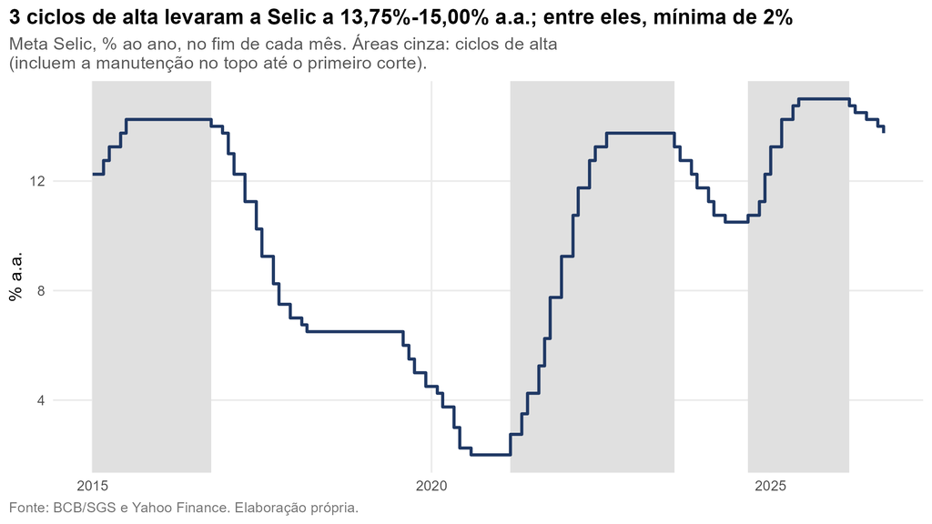

Figura 1: Meta Selic no fim de cada mês. As áreas cinza marcam os ciclos de alta.

**Por que os setores deveriam reagir de forma diferente?**

- **Varejo:** depende de crédito ao consumidor e de consumo de bens duráveis, e muitas empresas são avaliadas pelo crescimento futuro. Juros mais altos encarecem o crédito, esfriam as vendas e reduzem o valor presente dos lucros futuros. Espera-se **relação negativa** (H1).
- **Bancos:** juros mais altos podem ampliar a margem financeira (diferença entre o que o banco cobra e o que paga), mas também aumentam a inadimplência. O efeito líquido tende a ser **fraco ou até positivo** (H2).
- **Utilities** (energia e saneamento): receitas reguladas e demanda estável, que pouco dependem do ciclo econômico. Espera-se **baixa sensibilidade** (H3).
- **Assimetria:** o mercado pode reagir de forma diferente a altas e a cortes, ou conforme a fase do ciclo de juros (H4).

# 2 Dados e metodologia

## 2.1 Dados

Tabela 2: Composição das cestas setoriais

| Setor | Ativos |
| --- | --- |
| Bancos | ITUB4 (Itaú), BBDC4 (Bradesco), BBAS3 (Banco do Brasil) |
| Varejo | LREN3 (Lojas Renner), MGLU3 (Magazine Luiza), RADL3 (Raia Drogasil) |
| Utilities | EQTL3 (Equatorial), CMIG4 (Cemig), SBSP3 (Sabesp) |
| Mercado | Ibovespa (^BVSP) |

- **Preços:** cotações diárias ajustadas por dividendos e desdobramentos (Yahoo Finance). O preço do mês é o do último pregão; o retorno mensal é a variação percentual simples.
- **Cestas:** média simples dos retornos das três ações de cada setor (pesos iguais).
- **Selic:** meta definida pelo Copom (Banco Central, série SGS 432), vigente no fim de cada mês. A **variação da Selic** ($\Delta Selic$) é a mudança da meta no mês, em pontos percentuais.
- **Ciclo:** direção do último movimento do Copom. Meses sem mudança herdam o ciclo vigente, o que resulta em 68 meses de alta e 73 de queda.
- **Validação:** a base passou nas 7 checagens automáticas (meses consecutivos, nenhum valor ausente, as 9 ações com retorno em todos os meses, valores dentro de faixas plausíveis).

## 2.2 Metodologia

A análise segue três etapas, da mais simples à mais rigorosa:

1. **Descritiva:** retorno, risco e retorno médio em cada ciclo da Selic.
2. **Correlações defasadas:** correlação entre o retorno do setor no mês $t$ e a variação da Selic no mesmo mês e em até três meses antes.
3. **Regressões** para cada setor $s$:

$$r_{s,t} = \alpha + \beta_1\,\Delta Selic_t + \beta_2\, r_{Ibov,t} + \varepsilon_t
\qquad \text{(modelo 1)}$$

$$r_{s,t} = \alpha + \beta_1\,\Delta Selic_t + \beta_2\, r_{Ibov,t} + \gamma\, Alta_t
+ \beta_3\,(\Delta Selic_t \times Alta_t) + \varepsilon_t
\qquad \text{(modelo 2)}$$

**NotaComo ler os coeficientes**

- $\beta_1$ (modelo 1) é a resposta do setor a +1 p.p. na Selic, **descontado o movimento da bolsa**. Incluir o Ibovespa é essencial: sem ele, estaríamos medindo o quanto a bolsa inteira reage aos juros, e não o que é próprio de cada setor.
- $\beta_2$ é o **beta de mercado**: acima de 1, o setor amplifica a bolsa; abaixo de 1, suaviza.
- No modelo 2, $Alta_t$ vale 1 nos ciclos de alta. Como toda alta da Selic ocorre num ciclo de alta e todo corte num ciclo de queda, $\beta_1$ mede, na prática, a reação a **cortes**, e $\beta_1 + \beta_3$ a reação a **altas**. $\beta_3$ testa se as duas são diferentes (H4).
- Os erros-padrão são de **Newey-West** (3 defasagens), que permanecem válidos, em amostras grandes, quando a variância dos retornos muda com o tempo e quando há correlação entre meses próximos, como é comum em séries financeiras.
- Os coeficientes medem **associação**, não efeito causal (veja as Limitações).

# 3 Resultados

## 3.1 Desempenho: todos os setores superaram o Ibovespa

Tabela 3: Retorno e risco, de jan/2015 a set/2026 (média mensal, acumulado no período e anualizado)

| Série | Média (% a.m.) | Acumulado (%) | Anual (% a.a.) | Volatilidade (% a.a.) | Pior mês (%) | Melhor mês (%) |
| --- | --- | --- | --- | --- | --- | --- |
| Bancos | 1,42 | 319 | 13,0 | 31,1 | -33,3 | 32,5 |
| Varejo | 1,83 | 502 | 16,5 | 36,8 | -24,9 | 31,4 |
| Utilities | 1,93 | 863 | 21,3 | 27,1 | -32,7 | 30,3 |
| Ibovespa | 1,13 | 273 | 11,8 | 21,4 | -29,9 | 17,0 |

As três cestas renderam mais que o Ibovespa (11,8% ao ano). As utilities lideraram, com 21,3% ao ano e volatilidade menor que a de bancos e varejo. O varejo foi o setor mais arriscado (36,8% de volatilidade anual).

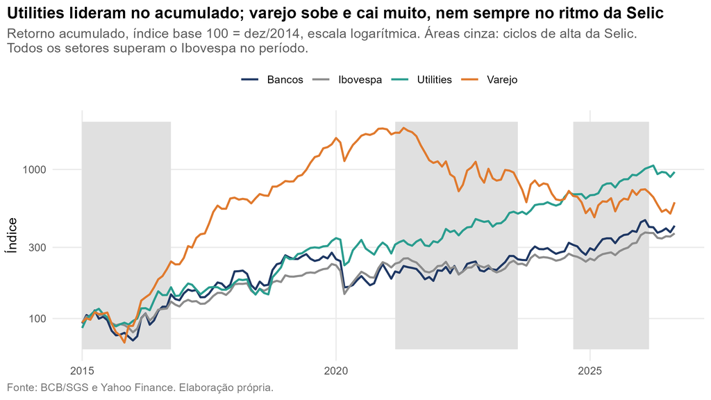

Figura 2: Retorno acumulado, base 100 = dez/2014, escala logarítmica.

A Figura 2 mostra por que é preciso cuidado com conclusões visuais. O varejo subiu 702% no ciclo de cortes de out/2016 a fev/2021, o que parece confirmar a H1. Mas, no ciclo de cortes de ago/2023 a ago/2024, o setor caiu 25%, mesmo com os juros em queda. A trajetória do varejo não acompanha a Selic de forma simples, o que é coerente com o resultado de robustez da seção 3.5.

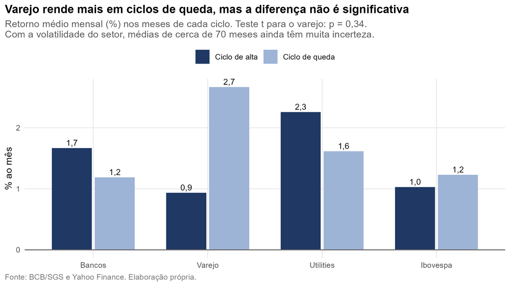

Figura 3: Retorno médio mensal em cada ciclo da Selic.

Na média simples (Figura 3), o varejo rendeu 2,7% ao mês nos ciclos de queda, contra 0,9% nos de alta. A diferença parece grande, mas **não é estatisticamente significativa** (teste t, p = 0,337): com volatilidade de 10,6% ao mês, médias de cerca de 70 meses ainda têm muita incerteza. Por isso, as conclusões se apoiam nas regressões a seguir.

## 3.2 Correlações: só o varejo se move contra a Selic

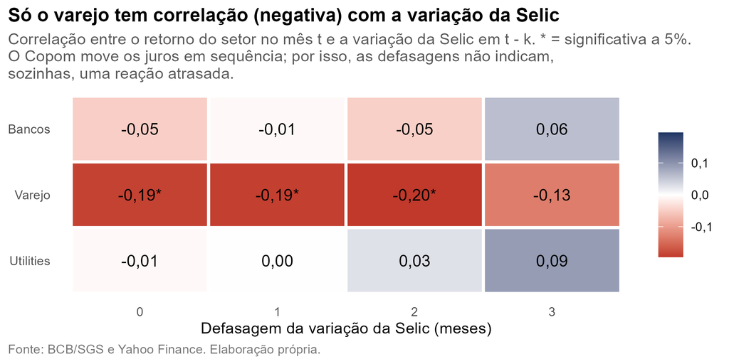

Figura 4: Correlação entre o retorno do setor no mês t e a variação da Selic em t − k.

Apenas o varejo tem correlação significativa com a variação da Selic (Figura 4): negativa, de cerca de -0,19, no mesmo mês e também nas defasagens de 1 e 2 meses. Isso **não prova** que a reação seja atrasada: o Copom move os juros em sequência, e a própria variação da Selic tem autocorrelação de 0,42 a 0,59 nas defasagens de 1 a 3 meses. Assim, um mês de alta tende a vir depois de outros meses de alta. Bancos e utilities têm correlações próximas de zero em todas as defasagens.

## 3.3 Regressões: varejo sensível, bancos e utilities não (H1, H2 e H3)

Tabela 4: Modelo 1: efeito de +1 p.p. na Selic sobre o retorno mensal do setor (p.p.), controlando pelo Ibovespa

| Setor | Efeito da Selic (β1) | IC 95% | p-valor | Beta de mercado (β2) | R² |
| --- | --- | --- | --- | --- | --- |
| Bancos | +0,27 | [-1,27; 1,81] | 0,729 | 1,30 | 0,80 |
| Varejo | -3,36 | [-5,70; -1,03] | 0,005 | 1,13 | 0,46 |
| Utilities | +0,84 | [-0,87; 2,54] | 0,333 | 0,99 | 0,60 |

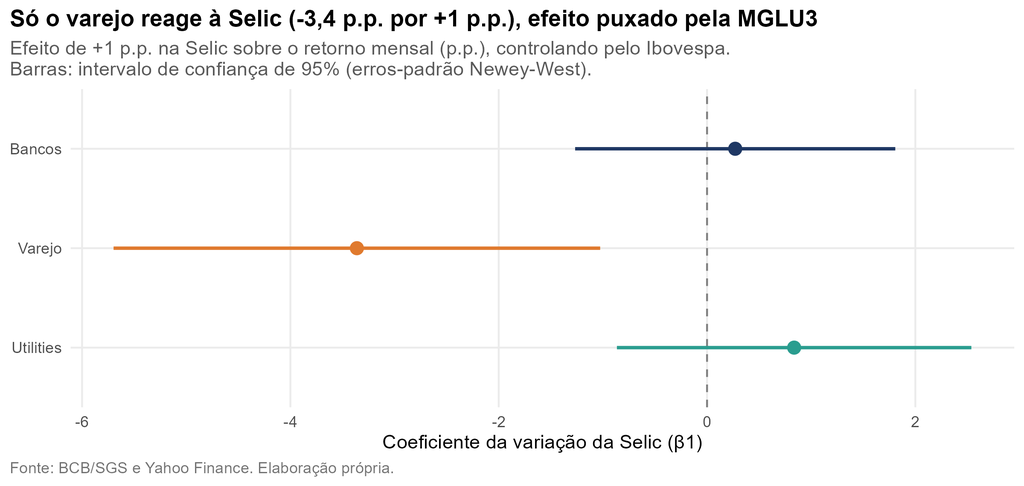

Figura 5: Efeito de +1 p.p. na Selic, com intervalo de confiança de 95%.

- **H1 (varejo):** o coeficiente é -3,36 (p = 0,005), e o intervalo de confiança fica inteiro abaixo de zero (Figura 5). É o único setor com efeito significativo.
- **H2 (bancos):** o efeito é +0,27 e não significativo. Não há evidência de que os bancos ganhem com a alta de juros, e a estimativa é bem menor, em módulo, que a do varejo. O dado que mais chama atenção é o beta de 1,30, o maior dos três setores, e o R² de 0,80: o retorno dos bancos é quase todo explicado pela bolsa.
- **H3 (utilities):** o efeito é +0,84 e não significativo: não há sensibilidade detectável à Selic. Mas o beta de 0,99 mostra que o setor não é defensivo em relação à bolsa: ele acompanha o Ibovespa quase 1 para 1.

**Ressalva sobre H2 e H3.** As duas hipóteses comparam bancos e utilities com o varejo. Essa comparação depende da MGLU3: sem ela, o varejo também não reage (seção 3.5). Além disso, não testamos formalmente se os coeficientes dos setores diferem entre si. Por isso, o veredito é “apoiada” no sentido de **ausência de efeito detectável**, e não de prova de que o setor é imune aos juros.

## 3.4 Altas e cortes da Selic (H4)

Tabela 5: Modelo 2: retorno (p.p.) por 1 p.p. de variação da Selic, separando cortes e altas

| Setor | Cortes, ciclo de queda (β1) | Altas, ciclo de alta (β1 + β3) | Diferença: p-valor de β3 |
| --- | --- | --- | --- |
| Bancos | -0,49 (p = 0,697) | -0,18 (p = 0,905) | 0,872 |
| Varejo | -5,14 (p = 0,033) | -2,68 (p = 0,147) | 0,402 |
| Utilities | +0,04 (p = 0,982) | +0,67 (p = 0,646) | 0,803 |

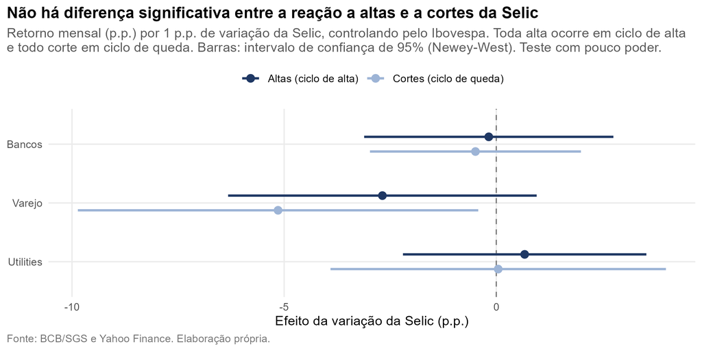

Figura 6: Reação a altas e a cortes da Selic, com intervalo de confiança de 95%.

Nenhum setor reage de forma significativamente diferente a altas e a cortes (Tabela 5): os p-valores da diferença vão de 0,40 a 0,87. No varejo, a estimativa para cortes (-5,14) é maior, em módulo, que para altas (-2,68), mas os intervalos de confiança se sobrepõem bastante (Figura 6). Com 24 altas e 33 cortes no período, o teste tem pouco poder: uma diferença moderada poderia existir sem ser detectada. **H4 não é apoiada** pelos dados.

## 3.5 Robustez: o efeito do varejo vem da MGLU3

A MGLU3 teve meses extremos no período (retornos acima de 30% em módulo em vários meses). Para saber se ela domina o resultado do varejo, a regressão foi refeita sem ela e com cada ação sozinha:

Tabela 6: Efeito de +1 p.p. na Selic sobre o varejo, por especificação (modelo 1)

| Especificação | Efeito da Selic | IC 95% | p-valor | R² |
| --- | --- | --- | --- | --- |
| Varejo com MGLU3 (cesta) | -3,36 | [-5,70; -1,03] | 0,005 | 0,46 |
| Varejo sem MGLU3 | -0,21 | [-2,04; 1,63] | 0,825 | 0,49 |
| Só LREN3 | -0,24 | [-3,39; 2,91] | 0,880 | 0,46 |
| Só MGLU3 | -9,67 | [-15,68; -3,66] | 0,002 | 0,24 |
| Só RADL3 | -0,17 | [-2,38; 2,04] | 0,879 | 0,18 |

O resultado é claro: a MGLU3 sozinha tem efeito de -9,67 p.p. (p = 0,002), enquanto LREN3 e RADL3, sozinhas ou juntas, não mostram reação detectável à Selic. Portanto, **H1 é apoiada só em parte**: há um efeito negativo na cesta de varejo, mas ele reflete uma empresa, e não o setor como um todo.

# 4 Implicações para o investidor

- **A exposição a juros parece ser de empresa, não de setor.** No varejo, a sensibilidade apareceu só na MGLU3, possivelmente por combinar venda a crédito, endividamento e valor de mercado apoiado no crescimento futuro (hipótese não testada aqui). Lojas Renner e Raia Drogasil não mostraram reação detectável. Para avaliar a exposição a juros, vale olhar a empresa, e não só o setor.
- **Não há evidência de que bancos protejam contra a alta de juros.** A tese de que “juros altos favorecem bancos” não aparece nos retornos mensais. O que define o risco dos bancos é a bolsa (beta de 1,30).
- **Utilities: sem sensibilidade detectável à Selic, mas com risco de bolsa.** O setor teve o melhor retorno do período, mas acompanha o Ibovespa quase 1 para 1.
- **Escolher setor pelo ciclo de juros não encontra apoio nos dados.** Não houve diferença significativa entre a reação a altas e a cortes.

*Este relatório tem fins acadêmicos e não constitui recomendação de investimento.*

# 5 Limitações

- **Cestas pequenas:** com 3 ações por setor, uma ação volátil domina o resultado, como mostrou a MGLU3. Cestas maiores ou ponderadas por valor de mercado dariam uma visão mais setorial, e a conclusão “de empresa, não de setor” precisaria ser confirmada com mais empresas.
- **Viés de sobrevivência:** as ações foram escolhidas entre empresas relevantes hoje, que sobreviveram ao período. Empresas que encolheram ou saíram da bolsa ficam de fora.
- **Variação realizada, não surpresa:** a análise usa a mudança da Selic, e não a diferença entre a decisão e o que o mercado esperava. Uma alta já esperada pode estar nos preços antes da reunião do Copom, o que tende a reduzir os efeitos medidos.
- **Frequência mensal:** reações concentradas nos dias das reuniões do Copom podem se diluir no mês.
- **Associação, não causalidade:** o Banco Central reage à inflação e à atividade econômica, que também afetam as ações. Os coeficientes medem associação, não o efeito causal dos juros.
- **Definição de ciclo:** meses sem mudança herdam o ciclo vigente; não há estado “estável”. Com isso, ciclo e direção do movimento se confundem: o teste de H4 compara altas com cortes, e não o início com o fim de um ciclo.
- **Poder estatístico e múltiplos testes:** com 24 altas e 33 cortes, diferenças moderadas podem passar despercebidas. Por outro lado, com 12 correlações testadas a 5%, é de esperar que alguma seja significativa por acaso.

# 6 Reprodutibilidade

Todo o projeto é reproduzível em R. Os scripts 03 a 05 montam e validam a base e rodam a análise a partir dos dados brutos salvos; `quarto render` gera este relatório e o tutorial. Os números do texto e das tabelas são lidos de `resultados/tabelas/`, e os títulos dos gráficos são calculados pelo próprio script de análise, para que tudo acompanhe uma eventual atualização dos dados. O passo a passo, com o código comentado, está no **tutorial** que acompanha este relatório.

**Fontes:** Banco Central do Brasil (SGS, séries 432 e 433) e Yahoo Finance. Dados coletados em 28/10/2026.